# Hierarchical Spatial Interpolation of Extremes

Prerequisite to MS Stat Thesis

Siegfred Roi L. Codia

## **Reading PH Rainfall Maxima Data**

```r
library(tidyverse)
stations <- read_csv("NOAA PH Weather Stations.csv")
max_data <- read_csv("max.spread.fixed.csv")
library(geojsonio)
library(broom)
provinces <- geojson_read("Data/Admin Boundaries/provinces.geojson",  what = "sp")
provinces <- tidy(provinces)
```

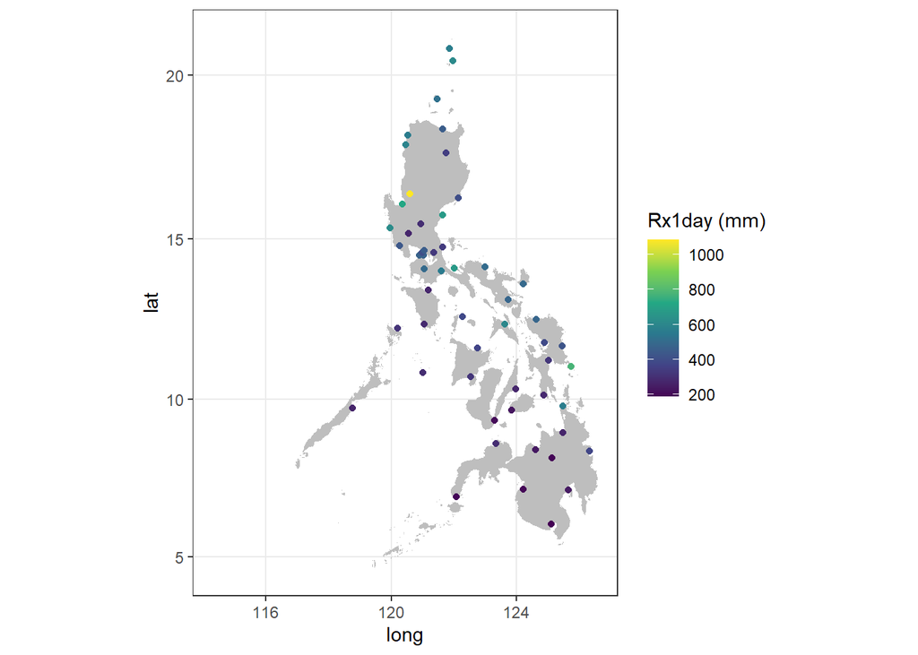

```r
library(ggplot2)
ph_map <- ggplot() +
    geom_polygon(data = provinces,
                 aes( x = long, y = lat,
                      group = group), fill="gray") +
    theme_void() +
    coord_map()+
    theme_bw()

ph_map +
        geom_point(data = stations,
                   aes(x = LON, y = LAT, color = `Rx1day (mm)`))+
        scale_color_viridis_c()
```

## **Fitting pointwise GEVD distributions**

We first load the EnvStats package and create custom function to extract parameters directly.

```r
library(EnvStats)
gevd_pars <- function(x){egevd(x)$parameters}
```

Now performing the estimation per column in the data frame.

```r
parameters <- sapply(select(max_data, -YEAR), gevd_pars)%>%t()%>%as.data.frame()
```

Creating the data frame that contains the GEVD parameters per weather station…

```r
parameters$"Station Name" <- row.names(parameters)
stations_pars <- full_join(stations,parameters, by = "Station Name")
stations_pars
```

| Region | Administrative Province | Station Name | LAT | LON | ALT | Rx1day (mm) | Period Covered | location | scale | shape |
| --- | --- | --- | --- | --- | --- | --- | --- | --- | --- | --- |
| I | llocos Norte | Laoag | 18.178 | 120.532 | 7.6 | 564.2 | 1907-2018 | 197.39484 | 125.63787 | 0.31296762 |
| I | llocos Sur | Sinait-Vigan | 17.883 | 120.467 | 570.0 | 594.1 | 1903-2018 | 127.85800 | 89.56759 | 0.25733466 |
| I | Pangasinan | Dagupan | 16.082 | 120.350 | 20.0 | 722.6 | 1903-2018 | 128.72933 | 86.46773 | -0.01009950 |
| CAR | Benguet | Baguio | 16.400 | 120.600 | 15010.0 | 1085.8 | 1902-2018 | 249.22982 | 166.16876 | -0.06071492 |
| II | Batanes | Basco Radar | 20.433 | 121.967 | 1670.0 | 616.4 | 1903-2018 | 130.75817 | 45.95601 | -0.37062343 |
| II | Batanes | Itbayat | 20.800 | 121.850 | 1240.0 | 572.3 | 1971-2018 | 143.42977 | 64.76931 | -0.19238064 |
| II | Cagayan | Aparri | 18.367 | 121.633 | 30.0 | 453.1 | 1903-2018 | 96.02950 | 73.37288 | -0.06778857 |
| II | Cagayan | Calayan | 19.267 | 121.467 | 130.0 | 522.2 | 1919-2018 | 46.77771 | 44.78041 | -0.13246771 |
| II | Cagayan | Tuguegarao | 17.633 | 121.750 | 620.0 | 349.7 | 1902-2018 | 131.44313 | 74.18083 | 0.17786686 |
| III | Aurora | Baler Radar | 15.750 | 121.633 | 1780.0 | 675.6 | 1949-2018 | 133.47112 | 56.98572 | 0.10250778 |

[output cut: 45 more lines]

### Visualization

```r
library(tidyverse)
rl_gathered <- stations_pars |>
    mutate(rl_5 = qgevd(1-1/5, location = location, scale = scale, shape = shape),
           rl_50 = qgevd(1-1/50, location = location, scale = scale, shape = shape),
           rl_100 = qgevd(1-1/100, location = location, scale = scale, shape = shape)) |>
    select(`Station Name`, LAT, LON, rl_5, rl_50, rl_100) |>
    pivot_longer(cols= c(rl_5, rl_50, rl_100),
                 names_to = "Return Period",
                 values_to = "Return Level") |>
    mutate("Return Period" = ordered(`Return Period`, levels = c("rl_5", "rl_50", "rl_100")))
```

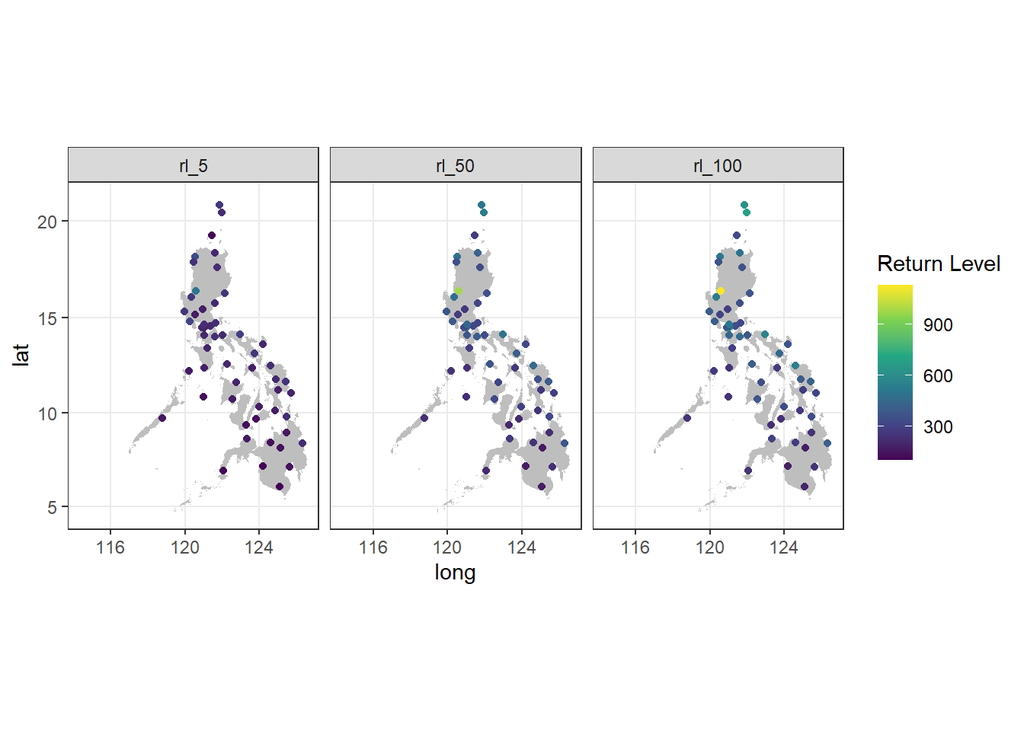

```r
ph_map +
    geom_point(data = rl_gathered, aes(x = LON, y = LAT, color = `Return Level`))+
    facet_wrap(.~`Return Period`)+
    scale_color_viridis_c()+
    theme_bw()
```

## **Spatial Interpolation**

Recall that the `stations_pars` data frame contains longitude and latitude coordinates of each weather station and the corresponding estimated GEVD parameters of the annual maxima. This will be the source data for interpolation.

```r
stations_pars
```

| Region | Administrative Province | Station Name | LAT | LON | ALT | Rx1day (mm) | Period Covered | location | scale | shape |
| --- | --- | --- | --- | --- | --- | --- | --- | --- | --- | --- |
| I | llocos Norte | Laoag | 18.178 | 120.532 | 7.6 | 564.2 | 1907-2018 | 197.39484 | 125.63787 | 0.31296762 |
| I | llocos Sur | Sinait-Vigan | 17.883 | 120.467 | 570.0 | 594.1 | 1903-2018 | 127.85800 | 89.56759 | 0.25733466 |
| I | Pangasinan | Dagupan | 16.082 | 120.350 | 20.0 | 722.6 | 1903-2018 | 128.72933 | 86.46773 | -0.01009950 |
| CAR | Benguet | Baguio | 16.400 | 120.600 | 15010.0 | 1085.8 | 1902-2018 | 249.22982 | 166.16876 | -0.06071492 |
| II | Batanes | Basco Radar | 20.433 | 121.967 | 1670.0 | 616.4 | 1903-2018 | 130.75817 | 45.95601 | -0.37062343 |
| II | Batanes | Itbayat | 20.800 | 121.850 | 1240.0 | 572.3 | 1971-2018 | 143.42977 | 64.76931 | -0.19238064 |
| II | Cagayan | Aparri | 18.367 | 121.633 | 30.0 | 453.1 | 1903-2018 | 96.02950 | 73.37288 | -0.06778857 |
| II | Cagayan | Calayan | 19.267 | 121.467 | 130.0 | 522.2 | 1919-2018 | 46.77771 | 44.78041 | -0.13246771 |
| II | Cagayan | Tuguegarao | 17.633 | 121.750 | 620.0 | 349.7 | 1902-2018 | 131.44313 | 74.18083 | 0.17786686 |
| III | Aurora | Baler Radar | 15.750 | 121.633 | 1780.0 | 675.6 | 1949-2018 | 133.47112 | 56.98572 | 0.10250778 |

[output cut: 45 more lines]

```r
library(sp)
stations_pars_spdf <- SpatialPointsDataFrame(stations_pars,
                                             coords = stations[,c("LON", "LAT")])

ph_grid <- expand.grid(x = seq(from = min(provinces$long),
                               to = max(provinces$long), length.out = 80),
                       y = seq(from = min(provinces$lat),
                               to = max(provinces$lat), length.out = 100))
coordinates(ph_grid) <- ~x + y
```

### **Inverse Distance Weighting**

```r
idw_loc   <- gstat::idw(location ~ 1, stations_pars_spdf, ph_grid, idp = 2.0)
```

```
## [inverse distance weighted interpolation]
```

```r
idw_scale <- gstat::idw(scale ~ 1, stations_pars_spdf, ph_grid, idp = 2.0)
```

```
## [inverse distance weighted interpolation]
```

```r
idw_shape <- gstat::idw(shape ~ 1, stations_pars_spdf, ph_grid, idp = 2.0)
```

```
## [inverse distance weighted interpolation]
```

```r
df_idw <- data.frame(x = ph_grid$x, y = ph_grid$y,
                     location = idw_loc$var1.pred,
                     scale = idw_scale$var1.pred,
                     shape = idw_shape$var1.pred)
```

Computation of return level values

```r
rl_idw <- df_idw |>
    mutate(rl_5 = qgevd(1-1/5, location = location, scale = scale, shape = shape),
           rl_50 = qgevd(1-1/50, location = location, scale = scale, shape = shape),
           rl_100 = qgevd(1-1/100, location = location, scale = scale, shape = shape)) |>
    select(x, y, rl_5, rl_50, rl_100) |>
    pivot_longer(cols= c(rl_5, rl_50, rl_100),
                 names_to = "Return Period",
                 values_to = "Return Level") |>
    mutate("Return Period" = ordered(`Return Period`, levels = c("rl_5", "rl_50", "rl_100")))
rl_idw
```

| x | y | Return Period | Return Level |
| --- | --- | --- | --- |
| 114.2779 | 4.587399 | rl_5 | 192.0245 |
| 114.2779 | 4.587399 | rl_50 | 308.1474 |
| 114.2779 | 4.587399 | rl_100 | 337.9519 |
| 114.4339 | 4.587399 | rl_5 | 191.7285 |
| 114.4339 | 4.587399 | rl_50 | 307.6763 |
| 114.4339 | 4.587399 | rl_100 | 337.4393 |
| 114.5900 | 4.587399 | rl_5 | 191.4250 |
| 114.5900 | 4.587399 | rl_50 | 307.1950 |
| 114.5900 | 4.587399 | rl_100 | 336.9163 |
| 114.7460 | 4.587399 | rl_5 | 191.1139 |

[output cut: 9990 more lines]

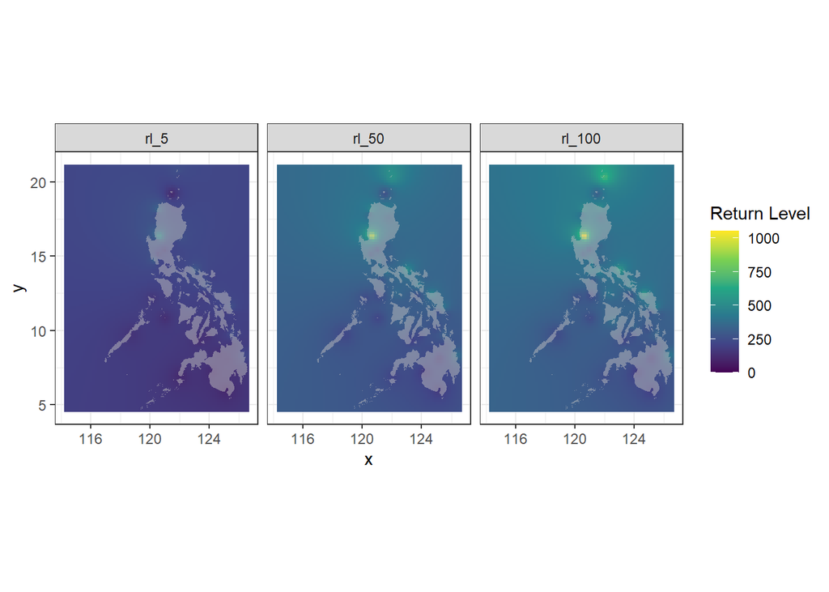

```r
ggplot()+
    geom_raster(data = rl_idw, aes(x = x, y = y, fill = `Return Level`))+
    scale_fill_viridis_c(limits = c(0, max(rl_idw$`Return Level`)))+
    coord_fixed()+
    theme_bw()+
    facet_wrap(.~`Return Period`)+
    geom_polygon(data = provinces, aes( x = long, y = lat,
                                          group = group), fill="gray", alpha = 0.5)
```

### **Kriging**

```r
library(gstat)
v_loc <- variogram(location ~ 1, stations_pars_spdf)
fit_loc <- fit.variogram(v_loc, vgm(model = "Sph"))
krig_loc   <- gstat::krige(location ~ 1,
                           stations_pars_spdf,
                           ph_grid,
                           model = fit_loc)
```

```
## [using ordinary kriging]
```

```r
v_scale <- variogram(scale ~ 1, stations_pars_spdf)
fit_scale <- fit.variogram(v_scale, vgm(model = "Sph"))
krig_scale <- gstat::krige(scale ~ 1,
                           stations_pars_spdf,
                           ph_grid,
                           model = fit_scale)
```

```
## [using ordinary kriging]
```

```r
v_shape <- variogram(shape ~ 1, stations_pars_spdf)
fit_shape <- fit.variogram(v_shape, vgm(model = "Sph"))
krig_shape <- gstat::krige(shape ~ 1,
                           stations_pars_spdf,
                           ph_grid,
                           model = fit_shape)
```

```
## [using ordinary kriging]
```

```r
df_krig <- data.frame(x = ph_grid$x, y = ph_grid$y,
                     location = krig_loc$var1.pred,
                     scale = krig_scale$var1.pred,
                     shape = krig_shape$var1.pred)
```

Computation of return level values

```r
rl_krig <- df_krig |>
    mutate(rl_5 = qgevd(1-1/5, location = location, scale = scale, shape = shape),
           rl_50 = qgevd(1-1/50, location = location, scale = scale, shape = shape),
           rl_100 = qgevd(1-1/100, location = location, scale = scale, shape = shape)) |>
    select(x, y, rl_5, rl_50, rl_100) |>
    pivot_longer(cols= c(rl_5, rl_50, rl_100),
                 names_to = "Return Period",
                 values_to = "Return Level") |>
    mutate("Return Period" = ordered(`Return Period`, levels = c("rl_5", "rl_50", "rl_100")))
rl_idw
```

| x | y | Return Period | Return Level |
| --- | --- | --- | --- |
| 114.2779 | 4.587399 | rl_5 | 192.0245 |
| 114.2779 | 4.587399 | rl_50 | 308.1474 |
| 114.2779 | 4.587399 | rl_100 | 337.9519 |
| 114.4339 | 4.587399 | rl_5 | 191.7285 |
| 114.4339 | 4.587399 | rl_50 | 307.6763 |
| 114.4339 | 4.587399 | rl_100 | 337.4393 |
| 114.5900 | 4.587399 | rl_5 | 191.4250 |
| 114.5900 | 4.587399 | rl_50 | 307.1950 |
| 114.5900 | 4.587399 | rl_100 | 336.9163 |
| 114.7460 | 4.587399 | rl_5 | 191.1139 |

[output cut: 9990 more lines]

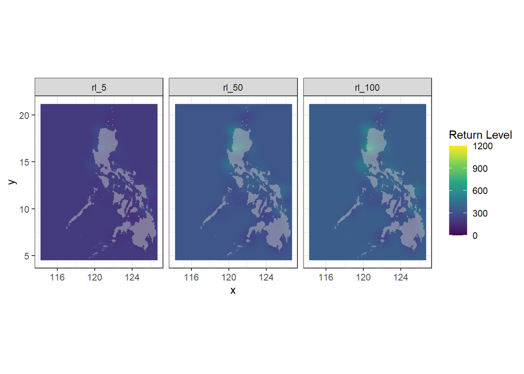

```r
ggplot()+
    geom_raster(data = rl_krig, aes(x = x, y = y, fill = `Return Level`))+
    scale_fill_viridis_c(limits = c(0, 1200))+
    coord_fixed()+
    theme_bw()+
    facet_wrap(.~`Return Period`)+
    geom_polygon(data = provinces, aes( x = long, y = lat,
                                          group = group), fill="gray", alpha = 0.5)
```

### **Spline**

```r
library(fields)
spline_loc   <- Tps(coordinates(stations_pars_spdf),
                    stations_pars_spdf$location, lambda = 0)
spline_scale   <- Tps(coordinates(stations_pars_spdf),
                    stations_pars_spdf$scale, lambda = 0)
spline_shape   <- Tps(coordinates(stations_pars_spdf),
                    stations_pars_spdf$shape, lambda = 0)
```

```r
df_spline <- as.data.frame(ph_grid) |>
    mutate(location = predict(spline_loc, as.data.frame(ph_grid)),
           scale  = predict(spline_scale, as.data.frame(ph_grid)),
           shape = predict(spline_shape, as.data.frame(ph_grid)))
```

Computation of return level values

```r
rl_spline <- df_spline |>
    mutate(rl_5 = qgevd(1-1/5, location = location, scale = scale, shape = shape),
           rl_50 = qgevd(1-1/50, location = location, scale = scale, shape = shape),
           rl_100 = qgevd(1-1/100, location = location, scale = scale, shape = shape)) |>
    select(x, y, rl_5, rl_50, rl_100) |>
    pivot_longer(cols= c(rl_5, rl_50, rl_100),
                 names_to = "Return Period",
                 values_to = "Return Level") |>
    mutate("Return Period" = ordered(`Return Period`, levels = c("rl_5", "rl_50", "rl_100")))
rl_idw
```

| x | y | Return Period | Return Level |
| --- | --- | --- | --- |
| 114.2779 | 4.587399 | rl_5 | 192.0245 |
| 114.2779 | 4.587399 | rl_50 | 308.1474 |
| 114.2779 | 4.587399 | rl_100 | 337.9519 |
| 114.4339 | 4.587399 | rl_5 | 191.7285 |
| 114.4339 | 4.587399 | rl_50 | 307.6763 |
| 114.4339 | 4.587399 | rl_100 | 337.4393 |
| 114.5900 | 4.587399 | rl_5 | 191.4250 |
| 114.5900 | 4.587399 | rl_50 | 307.1950 |
| 114.5900 | 4.587399 | rl_100 | 336.9163 |
| 114.7460 | 4.587399 | rl_5 | 191.1139 |

[output cut: 9990 more lines]

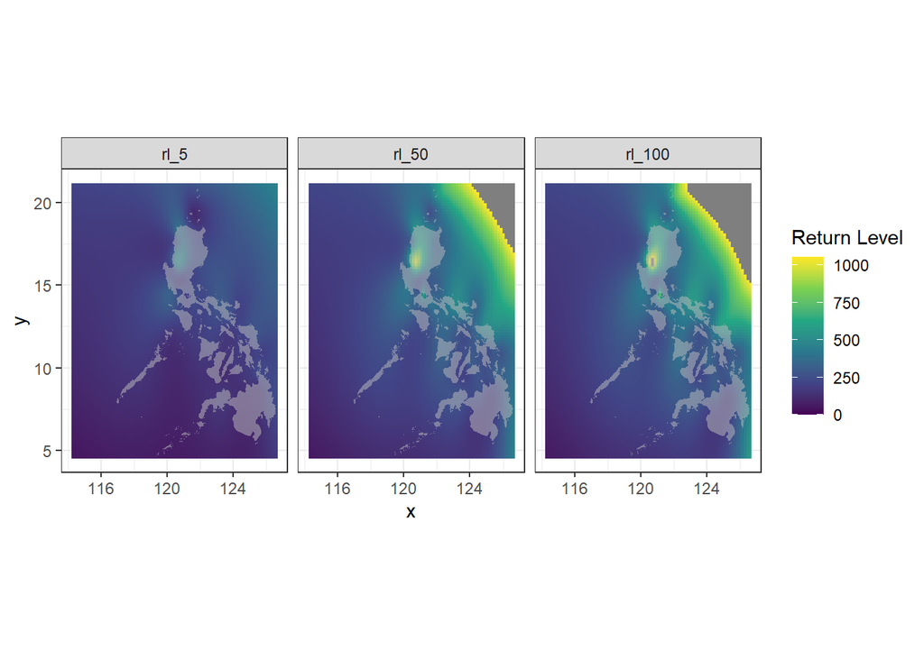

```r
ggplot()+
    geom_raster(data = rl_spline, aes(x = x, y = y, fill = `Return Level`))+
    scale_fill_viridis_c(limits = c(0, max(rl_idw$`Return Level`)))+
    coord_fixed()+
    theme_bw()+
    facet_wrap(.~`Return Period`)+
    geom_polygon(data = provinces, aes( x = long, y = lat,
                                          group = group), fill="gray", alpha = 0.5)
```

In the spline interpolation, from the graphs, there is a tendency that this model will over estimate when it comes to extrapolation of values outside the study region

## **Model Evaluation**

We then compare the quantiles of $GEVD(\{\tilde{\mu}_\alpha,\tilde{\sigma}_\alpha, \tilde{\xi}_\alpha\}$ to the empirical quantiles of the observed data.